# STAT7016 Assignment 4

Rui Qiu

2017-10-08

## Setting

```r
library(LearnBayes)
library(coda)
library(MASS)
library(MCMCpack)
library(mvtnorm)
library(car)

set.seed(7016)
```

## Problem 1

The files `school1.dat` through `school8.dat` give weekly hours spent on homework for students sampled from eight different schools. We want to obtain posterior distributions for the true means for the eight different schools using a hierarchical normal model with the following prior parameters:

$$\mu_0=7,\gamma_0^2=5,\tau_0^2=10,\eta_0=2,\sigma_0^2=15,\nu_0=2$$

### (a)

Run a Gibbs sampling algorithm to approximate the posterior distribution of $\{\mathbf{\theta},\sigma^2,\mu,\tau^2\}$. Assess the convergence of the Markov chain, and find the effective sample size for $\{\sigma^2,\mu,\tau^2\}$. Run the chain long enough so that the effective sample sizes are all above $1,000$.

### Solution:

```r
hw <- NULL
for (i in 1:8) {
    aschool <- read.table(paste0('school', i, '.dat'),header=F)
    aschool <- cbind(rep(i,length(aschool)),aschool)
    hw <- rbind(hw, aschool)
}
colnames(hw) <- c('school','hours')

# priors
mu0 <- 7; gamma20 <- 5; tau20 <- 10; eta0 <- 2; sigma20 <- 15; nu0 <- 2

# initial values (use sample means and sample variances)
n <- rep(NA,8)
ybar <- rep(NA,8)
svar <- rep(NA,8)
for (i in 1:8) {
    Yi <- hw[hw[,1]==i,2]
    n[i] <- length(Yi)
    ybar[i] <- mean(Yi)
    svar[i] <- var(Yi)
}

# initial theta estimates
theta <- ybar
sigma2 <- mean(svar)
mu <- mean(theta)
tau2 <- var(theta)

# Gibbs
K <- 10000
paras <- matrix(nrow=K,ncol=8+3)
colnames(paras) <- c("theta1","theta2","theta3","theta4","theta5",
                     "theta6","theta7","theta8","sigma2","mu","tau2")
for (i in 1:K) {
    # sample 8 thetas
    for (j in 1:8) {
        v <- 1/(n[j]/sigma2+1/tau2)
        e <- v*(ybar[j]*n[j]/sigma2+mu/tau2)
        theta[j] <- rnorm(1,e,sqrt(v))
    }

    # sample sigma2
    nun <- nu0 + sum(n)
    ss <- nu0*sigma20
    for (j in 1:8) {
        ss <- ss+sum((hw[hw[,1]==j,2]-theta[j])^2)
    }
    sigma2 <- 1/rgamma(1,nun/2,ss/2)

    # sample mu
    v <- 1/(8/tau2+1/gamma20)
    e <- v*(8*mean(theta)/tau2+mu0/gamma20)
    mu <- rnorm(1,e,sqrt(v))

    # sample tau2
    eta8 <- eta0+8
    ss <- eta0*tau20+sum((theta-mu)^2)
    tau2 <- 1/rgamma(1,eta8/2,ss/2)

    paras[i,1:8] <- theta
    paras[i,9:11] <- c(sigma2,mu,tau2)
}
post.sigma2 <- paras[,9]
post.mu <- paras[,10]
post.tau2 <- paras[,11]
```

We have 8 $\theta$s and 3 main parameters $\sigma^2,\mu,\tau^2$, we only pick $\theta_3$ and $\theta_6$ to plot the ACFs. Generally, they converge after such amount of iterations.

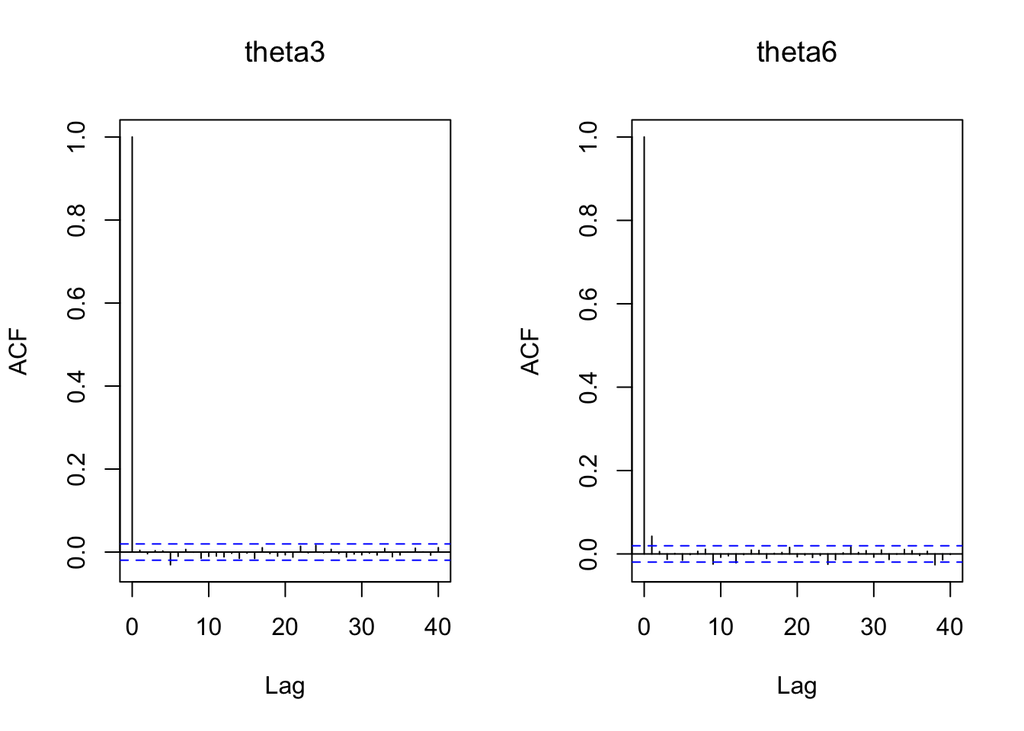

```r
par(mfrow=c(1,2))
acf(paras[,3],main="theta3")
acf(paras[,6],main="theta6")
```

```r
par(mfrow=c(1,1))
ef <- cbind(effectiveSize(post.sigma2),effectiveSize(post.mu),
            effectiveSize(post.tau2))
colnames(ef) <- c("sigma2","mu","tau2")
rownames(ef) <- "effective size"
ef
```

```
##                  sigma2       mu     tau2
## effective size 8932.689 8174.218 6876.188
```

As expected, the effect sample sizes of $\sigma^2,\mu,\tau^2$ all exceed $1000$.

### (b)

Compute posterior means and 95% confidence regions for $\{\sigma^2,\mu,\tau^2\}$. Also, compare the posterior densities to the prior densities, and discuss what was learned from the data.

### Solution:

The 95% confidence regions for $\sigma^2,\mu,\tau^2$ are shown below. The medians are also included.

```r
post.paras <- rbind(quantile(post.sigma2,prob=c(0.025,0.5,0.975)),
                    quantile(post.mu,prob=c(0.025,0.5,0.975)),
                    quantile(post.tau2,prob=c(0.025,0.5,0.975)))
rownames(post.paras) <- c("sigma2","mu","tau2")
post.paras
```

```
##             2.5%       50%     97.5%
## sigma2 11.700823 14.354105 17.920654
## mu      5.958100  7.578993  9.173253
## tau2    1.918046  4.643076 14.336684
```

The following set of plots include both priors and posteriors of 3 parameters. The priors are plotted in violet, while the posteriors are plotted in black.

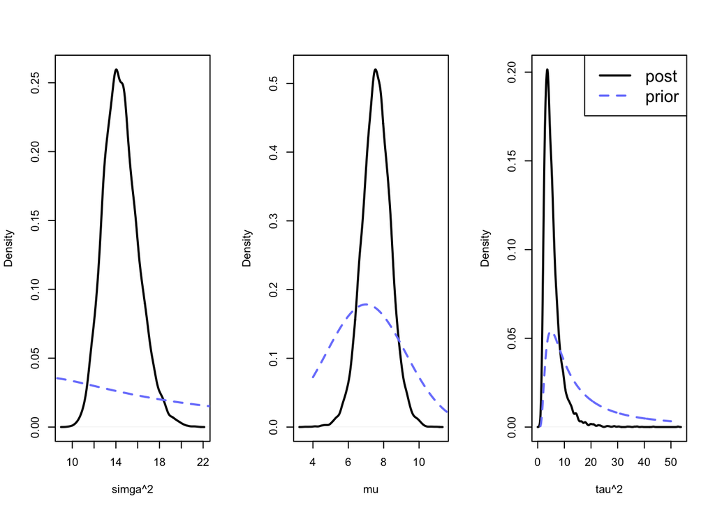

```r
par(mfrow=c(1,3))
plot(density(post.sigma2),xlab="simga^2",main="",lwd=2) # post sigma2
lines(seq(0,25,0.1),dinvgamma(seq(0,25,0.1),nu0/2,nu0*sigma20/2),lwd=2,
      lty=2,col="#7B84FC") # prior sigma2
plot(density(post.mu),xlab="mu",main="",lwd=2) # post mu
lines(seq(4,15,0.1),dnorm(seq(4,15,0.1),mu0,sqrt(gamma20)),lwd=2,
      lty=2,col="#7B84FC") # prior mu
plot(density(post.tau2),xlab="tau^2",main="",lwd=2) # post tau2
lines(seq(1,50,0.1),dinvgamma(seq(1,50,0.1),eta0/2,eta0*tau20/2),lwd=2,
      lty=2,col="#7B84FC") # prior tau2
legend("topright",legend=c("post","prior"),col=c("black","#7B84FC"),
       lty=c(1,2),lwd=c(2,2),cex=1.5)
```

```r
par(mfrow=c(1,1))
```

Based on the plots, it seems that prior estimates of $\mu$ and $\tau^2$ somewhat accurate, at least they both captured the basic shapes of posteriors. However, the prior of $\sigma^2$ deviates a lot from the its posterior. So in other words, our inital guess about the variability among students’ hours in each school is not very precise.

### (c)

Plot the posterior density for $R=\frac{\tau^2}{\sigma^2+\tau^2}$ and compare it to a plot of the prior density on $R$. Describe the evidence for between-school variation.

### Solution:

This part is similar to the previous one.

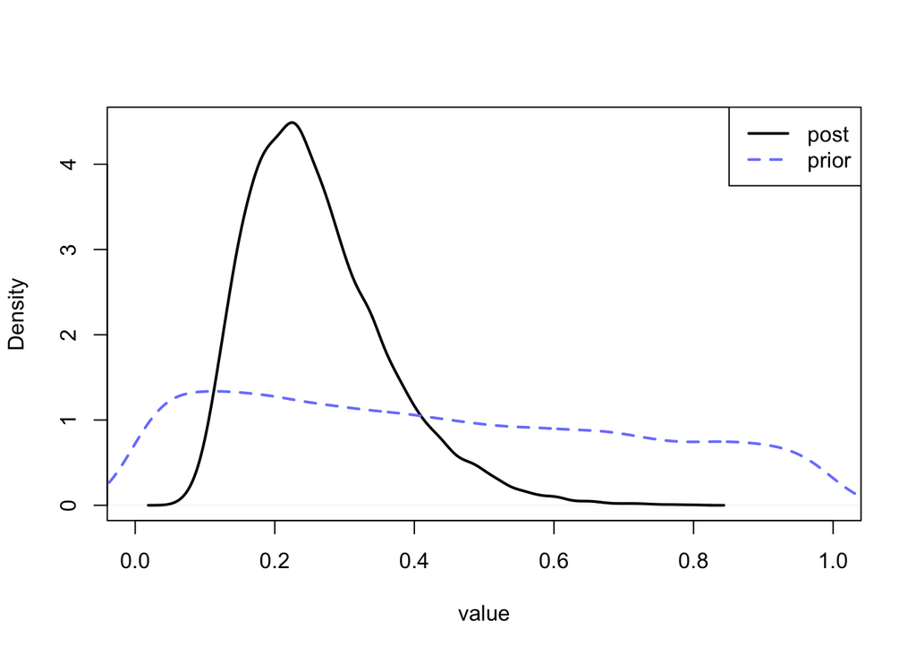

```r
# random sample 10000 pairs of tau20 and sigma20
prior.sims <- 10000
prior.tau20 <- (1/rgamma(prior.sims,eta0/2,eta0*tau20/2))
prior.sigma20 <- (1/rgamma(prior.sims,nu0/2,nu0*sigma20/2))
plot(density(post.tau2/(post.tau2+post.sigma2)),main="",xlab="value",
        lwd=2,lty=1,xlim=c(0,1))
lines(density(prior.tau20/(prior.tau20+prior.sigma20)),col="#7B84FC",lwd=2,lty=2)
legend("topright",lty=c(1,2),lwd=c(2,2),col=c("black","#7B84FC"),
       legend=c("post","prior"))
```

```r
mean(prior.tau20/(prior.tau20+prior.sigma20))
```

```
## [1] 0.4311038
```

```r
mean(post.tau2/(post.tau2+post.sigma2))
```

```
## [1] 0.2612869
```

Note that $R$ stands for the proportion of the total variability that between-group variability should be responsible for. From previous part, we seem to have a bad prior estimate of $\sigma^2$. However, after inference, we fix this problem manually so that about 26% of variability is caused by between-group variability.

### (d)

Obtain the posterior probability that $\theta_7$ is smaller than $\theta_6$, as well as the posterior probability that $\theta_7$ is the smallest of all the $\theta$’s.

### Solution:

```r
mean(paras[,7]<paras[,6])
```

```
## [1] 0.5235
```

```r
theta7.smallest <- 0
for (i in 1:K) {
    if (sort(paras[i,1:8],decreasing=F)[1]==paras[i,7]) {
        theta7.smallest <- theta7.smallest+1
    }
}
theta7.smallest/K
```

```
## [1] 0.3207
```

$$\begin{split}\Pr(\theta_7<\theta_6\mid\mathbf{y})&=0.5235\\
\Pr(\theta_7\text{ is the smallest among all}\ \theta\text{s}\mid\mathbf{y})&=0.3207
\end{split}$$

### (e)

Plot the sample averages $\bar{y}_1,\dots,\bar{y}_8$ against the posterior expectations of $\theta_1,\dots,\theta_8$, and describe the relationship. Also compute the sample mean of all observations and compare it to the posterior mean of $\mu$. Estimate the shrinkage effect for each school.

### Solution:

```r
comparison <- data.frame(school=1:8,
                         sample.mean=ybar,
                         post.expectation=colMeans(paras[,1:8]))
comparison
```

```
##        school sample.mean post.expectation
## theta1      1    9.464000         9.252736
## theta2      2    7.033478         7.108896
## theta3      3    7.953000         7.888101
## theta4      4    6.232083         6.390356
## theta5      5   10.765833        10.384387
## theta6      6    6.205000         6.384127
## theta7      7    6.132727         6.327621
## theta8      8    7.381000         7.419471
```

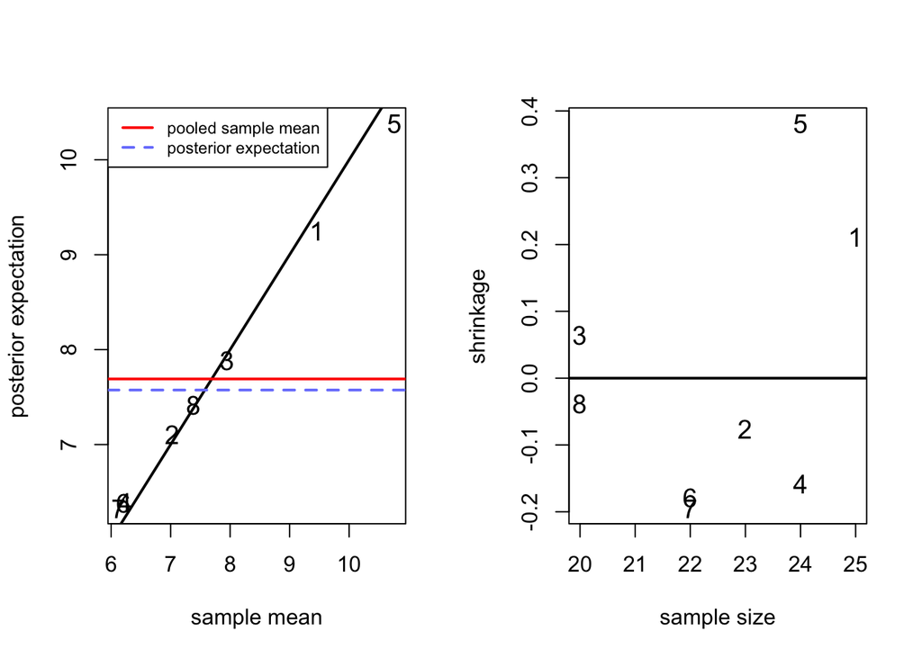

```r
par(mfrow=c(1,2))
plot(comparison$sample.mean,comparison$post.expectation,
     xlab="sample mean",ylab="posterior expectation",
     pch=paste0("",comparison$school),cex=1.2)
abline(0,1,lwd=2)
abline(h=mean(hw[,"hours"]),lty=1,col="red",lwd=2)
abline(h=mean(post.mu),lty=2,col="#7B84FC",lwd=2)
legend("topleft",legend=c("pooled sample mean","posterior expectation"),
       lty=c(1,2),col=c("red","#7B84FC"),lwd=c(2,2),cex=0.75)
plot(as.numeric(table(hw[,"school"])),
     comparison$sample.mean-comparison$post.expectation,
     pch=paste0("",comparison$school),ylab="shrinkage",xlab="sample size",
     cex=1.2)
abline(h=0,lty=1,lwd=2)
```

```r
par(mfrow=c(1,1))
c(mean(hw[,"hours"]), mean(post.mu)) # sample mean of all obs vs post mean of mu
```

```
## [1] 7.691278 7.574251
```

- Generally, the higher sample average $\bar{y}_i$ is, the corresponding higher posterior expectation $\theta_i$ is. From the plot on left hand side, we can see the mean-expectation pairs almost lie on the the 1-1 diagnoal line.
- The sample mean of all observations is $7.6912$, slightly higher than the posterior mean of $mu$ which is $7.5743$.
- The shrinkage effects are displayed in the plot on right hand side. But really, the shrinkages are negligible absolutely. This is mainly because the sample sizes of 8 schools are very close to each other.

## Problem 2

Younger male sparrows may or may not nest during a mating season, perhaps depending on their physical characteristics. Researchers have recorded the nesting success of 43 young male sparrows of the same age, as well as their wingspan, and the data appear in the file `msparrownest.dat`. Let $Y_i$ be the binary indicator that sparrow $i$ successfully nests, and let $x_i$ denote their wingspan. Our model for $Y_i$ is $\text{logit}[\text{Pr}(Y_i=1\mid\alpha,\beta,x_i)] =\alpha + \beta x_i$, where the logit function is given by $\text{logit}\left[\theta\right]=\log\left[\theta/(1-\theta)\right]$.

### (a)

Write out the joint sampling distribution $\prod^n_{i=1}p(y_i\mid \alpha,\beta,x_i)$ and simplify as much as possible.

### Solution:

Let $\theta_i=P(Y_i=1\mid \alpha,\beta,x_i)$, then we can solve for $\theta_i$:

$$\begin{split}
\log\left(\frac{\theta_i}{1-\theta_i}\right)&=\alpha+\beta x_i\\
\frac{\theta_i}{1-\theta_i}&=e^{\alpha+\beta x_i}\\
\theta_i&=\frac{\exp(\alpha+\beta x_i)}{1+\exp(\alpha+\beta x_i)}
\end{split}$$

We can treat the fraction expression as a probability $p_i=\frac{\exp{(\alpha+\beta x_i)}}{1+\exp({\alpha+\beta x_i)}}$ so that $Y_i\sim\text{Bernoulli}(p_i)$. Then we can write

$$p(y_i\mid \alpha,\beta,x_i)=p_i^{y_i}(1-p_i)^{1-y_i}$$

Suppose again $\eta_i=\exp{(\alpha+\beta x_i)}$, then the required joint sampling distribution can be rewritten as:

$$\begin{split}
\prod^n_{i=1}p(y_i\mid\alpha,\beta,x_i)&=\prod^n_{i=1}p_i^{y_i}(1-p_i)^{1-y_i}\\
&=\prod^n_{i=1}\left(\frac{\eta_i}{1+\eta_i}\right)^{y_i}\left(1-\frac{\eta_i}{1+\eta_i}\right)^{1-y_i}\\
&=\prod^n_{i=1}\left(\frac{\eta_i}{1+\eta_i}\right)^{y_i}\left(\frac{1}{1+\eta_i}\right)^{1-y_i}\\
&=\prod^n_{i=1}\frac{\eta_i^{y_i}}{(1+\eta_i)}\\
&=\prod^n_{i=1}\frac{\exp{y_i(\alpha+\beta x_i)}}{1+\exp{(\alpha+\beta x_i)}}
\end{split}$$

### (b)

Formulate a prior probability distribution over $\alpha$ and $\beta$ by considering the range of $\text{Pr}(Y=1\mid \alpha, \beta,x)$ as $x$ ranges over 10 to 15, the approximate range of the observed wingspans.

### Solution:

Consider the model in logit form, as Gelman says in his book, “TAKE LOG(it)!” If we want to have an uninformation prior about intercept, we should center our parameter of wingspan, i.e. $\beta$, around $0$. Similarly, if we want to have an uninformation prior about the coefficient of wingspan, then we should center the intercept, i.e. $\alpha$, around $0$. We can pick normal distributions as the distributions of $\alpha$ and $\beta$. Furthermore, as uninformative they are, basically we want the distributions to tell us almost “nothing”, so the variances should be pretty high. This means more variance is allowed.

Now we consider one extreme case that $\alpha=0$, then $x$ ranges from 10 to 15, we want to find the possible values of $\beta$ that allows from 0 to 1 change in logit (since logit is log-odds ratio).

We do some trials with R:

```r
logit(1e-5)
```

```
## [1] -11.51292
```

This means the logit of a small numberl ike $10^{-5}$ is around 10. Since $x=10$ is at its minimum, then most of beta priors would be in the range of $(-1,1)$. Hence, we assume $\beta\sim N(0,\sigma^2=0.25)$.

Similarly, we assume $\alpha\sim N(0,\sigma^2=25)$ such that when $\beta=0$, most of alpha priors will fall into a range such that the logit value is between $(-10,10)$.

### (c)

Implement a Metropolis algorithm that approximates $p(\alpha,\beta\mid\mathbf{y},\mathbf{x}).$ Adjust the proposal distribution to achieve a reasonable acceptance rate, and run the algorithm long enough so that the effective smaple size is at least 1,000 for each parameter.

### Solution:

```r
sparrow <- read.table("msparrownest.dat",header=F)
K <- 10000
y <- sparrow[,1]
n <- length(y)

ALPHA <- numeric(K)
BETA <- numeric(K)
accept.cts <- 0

x <- cbind(rep(1,n),sparrow[,2]) # wingspans

var.prop  <- 7*solve(t(x)%*%x)
prior.mean.theta <- c(0,0) # prior parameters
prior.sd.theta <- sqrt(c(25,0.25))

theta <- c(0,0) # initial values
log.p.y <- function(x,y,theta){
    p <- exp(x%*%theta)/(1+exp(x%*%theta))
    sum(dbinom(y,1,p,log=T))
}

p.theta <- function(theta){
    sum(dnorm(theta,prior.mean.theta,prior.sd.theta,log=T))
}

for (i in 1:K) {
    theta.star <- mvrnorm(1,theta,var.prop) # proposal
    if (log(runif(1))
        <(log.p.y(x,y,theta.star)+p.theta(theta.star))
        -(log.p.y(x,y,theta)+p.theta(theta))) {
        theta <- theta.star
        accept.cts <- accept.cts+1
    }
    ALPHA[i] <- theta[1]
    BETA[i] <- theta[2]
}
accept.cts/K
```

```
## [1] 0.3986
```

```r
c(effectiveSize(ALPHA),effectiveSize(BETA))
```

```
##     var1     var1
## 1462.229 1451.637
```

So far, the acceptance rate is around 40%, and the effective sizes of both $\alpha$ and $\beta$ exceed the critical value 1000.

### (d)

Compare the posterior densities for $\alpha$ and $\beta$ to their prior densities.

### Solution:

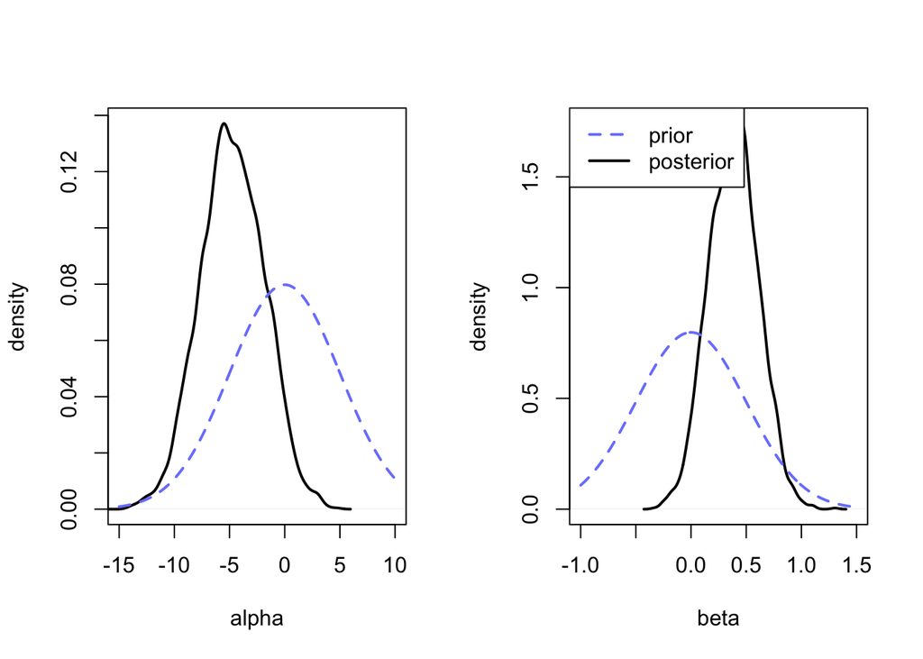

```r
par(mfrow=c(1,2))
# alpha prior
plot(density(ALPHA),type="l",xlab="alpha",ylab="density",
     main="",xlim=c(-15,10),lwd=2)
lines(seq(-15,10,0.1),dnorm(seq(-15,10,0.1),0,5),lty=2,col="#7B84FC",lwd=2)
plot(density(BETA),type="l",xlab="beta",ylab="density",
     main="",xlim=c(-1,1.5),lwd=2)
lines(seq(-1,1.5,0.01),dnorm(seq(-1,1.5,0.01),0,0.5),lty=2,col="#7B84FC",lwd=2)
legend("topleft",
       legend=c("prior","posterior"),lty=c(2,1),
       col=c("#7B84FC","black"),lwd=c(2,2))
```

Based on the plots above, our priors at least captured the basic shapes correctly, and didn’t deviate too much from the simulated posteriors. The priors have larger variances, and this is what we expect.

### (e)

Using output from the Metropolis algorithm, come up with a way to make a confidence band for the following function $f_{\alpha,\beta}(x)$ of wingspan:

$$f_{\alpha,\beta}(x)=\frac{\exp^{\alpha+\beta x}}{1+\exp^{\alpha+\beta x}}$$

where $\alpha$ and $\beta$ are the parameters in your sampling model. Make a plot of such a band.

### Solution:

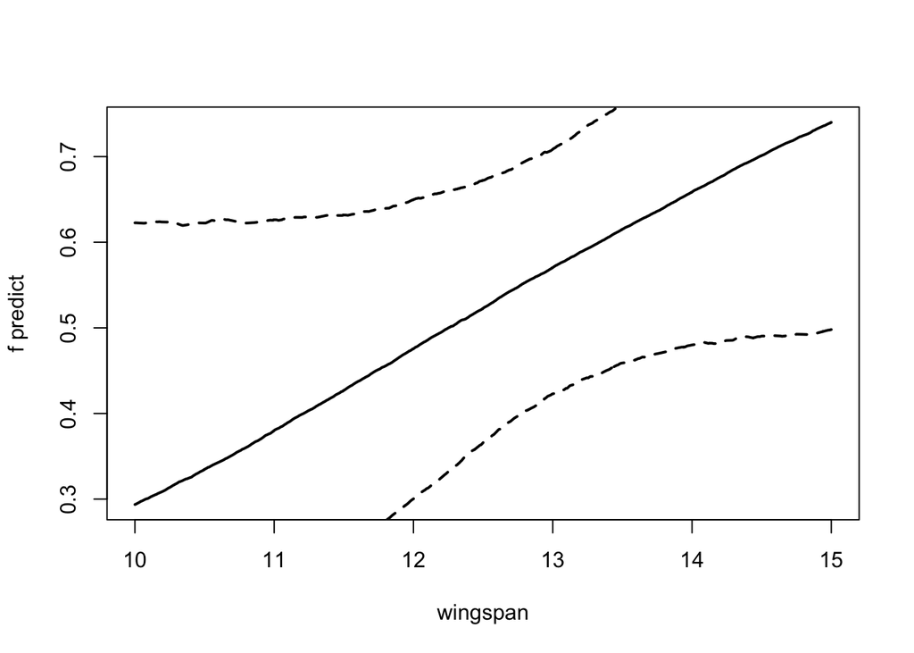

```r
span <- seq(10,15,0.005)
qtiles <- sapply(span,function(x){
    quantile(exp(ALPHA+BETA*x)/(1+exp(ALPHA+BETA*x)),probs=c(0.025,0.5,0.975))
})
plot(span,qtiles[2,],xlab="wingspan",type="l",ylab="f predict",main="",
     xlim=c(min(span),max(span)),
     ylim=c(min(qtiles[2,]),max(qtiles[2,])),lwd=2)
lines(span,qtiles[1,],lwd=2,lty=2)
lines(span,qtiles[3,],lwd=2,lty=2)
```

It looks like that the confidence region is quite wide. The most narrow or “accurate” part appears when the `wingspan` is from 12 to 13 (mean of estimations), probably because the data is concentrated at this part.

## Problem 3

The file `tplant.dat` contains data on the heights of ten tomato plants, grown under a variety of soil pH conditions. Each plant was measured twice. During the first measurement, each plant’s height was recorded and a reading of pH soil was taken. During the second measurement only plant height was measured, although it is assumed that pH levels did not vary much from measurement to measurement.

### (a)

Using ordinary least squares, fit a linear regression to the data, modelling plant height as a function of time (measurement period) and pH level. Interpret your model parameters.

### Solution:

```r
tplant <- read.table("tplant.dat",header=F)
y <- tplant[,1]
x <- cbind(tplant[,2],tplant[,3])
fit <- lm(y~x)
summary(fit)
```

```
##
## Call:
## lm(formula = y ~ x)
##
## Residuals:
##     Min      1Q  Median      3Q     Max
## -1.1225 -0.4307 -0.1101  0.4574  1.5301
##
## Coefficients:
##             Estimate Std. Error t value Pr(>|t|)
## (Intercept)   7.2087     0.5891   12.24 7.45e-10 ***
## x1            3.9910     0.3280   12.17 8.14e-10 ***
## x2            0.5778     0.1204    4.80 0.000167 ***
## ---
## Signif. codes:  0 '***' 0.001 '**' 0.01 '*' 0.05 '.' 0.1 ' ' 1
##
## Residual standard error: 0.7334 on 17 degrees of freedom
## Multiple R-squared:  0.9096, Adjusted R-squared:  0.899
## F-statistic: 85.55 on 2 and 17 DF,  p-value: 1.339e-09
```

The linear model is $y=7.2087+3.9910\cdot\text{time}+0.5778\cdot\text{pH}$.

The mean of intercept is $7.2087$, $3.9910$ is the amount of height increment when time changes from $0$ to $1$, $0.5778$ is the amount of height increment when pH value increases by $1$.

### (b)

Perform model diagnostics. In particular, carefully analyse the residuals and comment on possible violations of assumptions. In particular, assess (graphically or otherwise) whether or not the residuals within a plant are independent. What parts of your ordinary linear regression model do you think are sensitive to any violations of assumptions you may have detected?

### Solution:

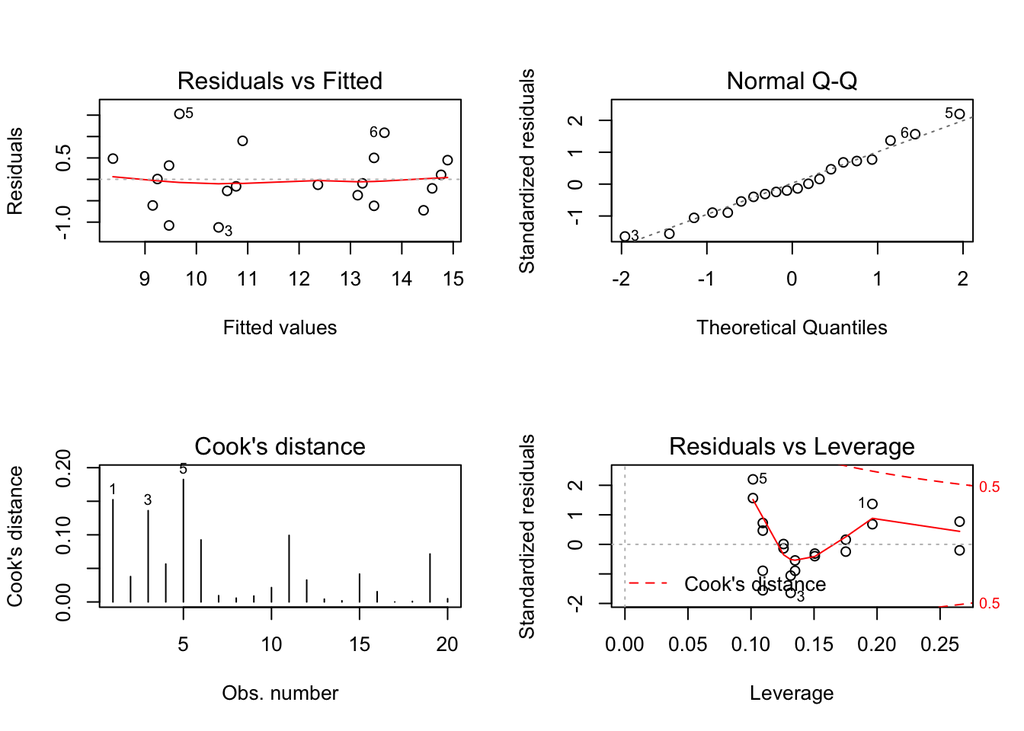

```r
par(mfrow=c(2,2))
# 4 basic diagnostic plot
plot(fit,which=c(1,2,4,5))
```

The basic diagnostic plots suggest no violations of assumptions. But if we take another look at the residuals versus other variables, some problems have emerged.

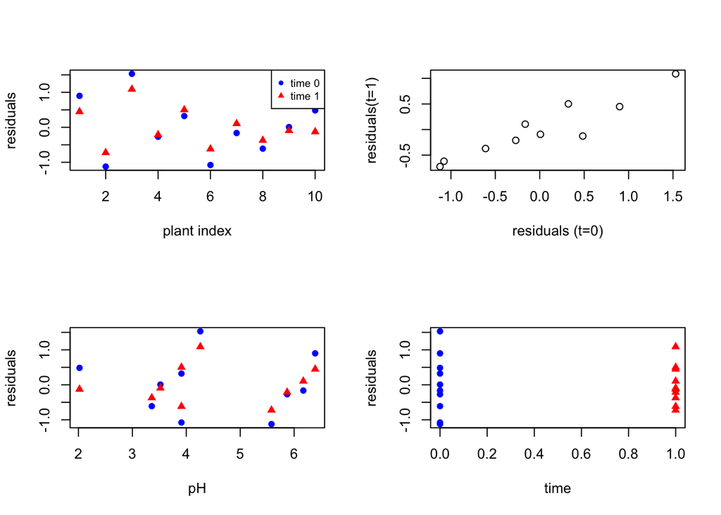

```r
par(mfrow=c(2,2))
res <- fit$residuals
res0 <- res[which(x[,1]==0)]
res1 <- res[which(x[,1]==1)]
plot(1:10,res0,ylim=c(min(res),max(res)),col="blue",pch=16,
     xlab="plant index",ylab="residuals")
points(1:10,res1,col="red",pch=17)
# triangle 1, circle 0
legend("topright",legend=c("time 0","time 1"),pch=c(16,17),col=c("blue","red"),
       cex=0.75)
plot(res0,res1,xlab="residuals (t=0)",ylab="residuals(t=1)")
plot(x[which(x[,1]==0),2],res0,xlab="pH",ylab="residuals",
     ylim=c(min(res),max(res)),xlim=c(min(x[,2]),max(x[,2])),
     col="blue",pch=16)
points(x[which(x[,1]==1),2],res1,col="red",pch=17)
plot(x[which(x[,1]==0),1],res0,xlab="time",ylab="residuals",
     ylim=c(min(res),max(res)),xlim=c(0,1),
     col="blue",pch=16)
points(x[which(x[,1]==1),1],res1,col="red",pch=17)
```

We investigated the relationships between residuals and plant index, soil pH and time. Also, we plotted the residuals within a plant in the same plot. It’s not hard for us to find out that the residuals within a plant are positively correlated, i.e. they are not independent. Therefore, the estimated coefficients of variable `time` might be problematic.

### (c)

Hypothesise a new model for your data which allows for observations within a plant to be correlated. Fit the model using a MCMC approximation to the posterior distribution, and present diagnostics for your approximation.

### Solution:

```r
K <- 7500
BETA <- array(NA,dim=c(K,3,10)) # only stores beta
X <- cbind(rep(1,20),x)
# initial values
Sigma <- solve(t(X)%*%X)
theta <-fit$coefficients
sigma2 <- var(fit$residuals)

# Gibbs
for (i in 1:K) {
    B <- NULL
    for (j in 1:10) {
        indices <- (2*j-1):(2*j) # for plant j, data 2j-1 and 2j correspond such plant
        delta <- solve(solve(Sigma)+t(X[indices,])%*%X[indices,]/sigma2)
        alpha <- delta%*%(solve(Sigma)%*%theta+t(X[indices,])%*%y[indices]/sigma2)
        beta <- t(as.matrix(rmvnorm(1,alpha,delta)))
        B <- cbind(B,beta)
    }
    BETA[i,,] <- B

    # update theta
    Lambda <- solve(diag(3)+10*solve(Sigma))
    beta.bar <- as.matrix(apply(B,1,mean))
    mu <- Lambda%*%(fit$coefficients+10*solve(Sigma)%*%beta.bar)
    theta <- t(rmvnorm(1,mu,Lambda))

    # update Sigma
    holder <- 0
    for (k in 1:10) {
        holder <- holder+(B[,k]-theta)%*%t(B[,k]-theta)
    }
    Sigma <- solve(rwish(11,solve(diag(3)+holder)))

    # update sigma2
    SSR <- 0
    for (l in 1:10) {
        indices2 <- (2*l-1):(2*l)
        SSR <- SSR+
            sum((y[indices2]-t(as.matrix(B[,l]))%*%t(X[indices2,]))^2)
    }
    sigma2 <- 1/rgamma(1,21/2,(1+SSR)/2)
}

eff.vec <- NULL
for (para in 1:3) {
    for (plant in 1:10) {
        eff.vec <- c(eff.vec,effectiveSize(BETA[,para,plant]))
    }
}
eff.vec
```

```
##     var1     var1     var1     var1     var1     var1     var1     var1
## 1347.959 2017.862 2281.918 1925.809 1668.076 1947.802 1819.927 1640.292
##     var1     var1     var1     var1     var1     var1     var1     var1
## 2104.727 1858.497 4532.831 4718.492 4347.889 4681.308 4729.356 4427.347
##     var1     var1     var1     var1     var1     var1     var1     var1
## 4928.442 4270.263 3974.351 4296.952 1403.746 2085.141 2024.049 2034.878
##     var1     var1     var1     var1     var1     var1
## 1727.887 2123.285 1788.740 1907.474 2252.613 1982.395
```

Since the effective sizes of all parameters exceed 1000, we beleive the new model is appropriate.

### (d)

Discuss the results of your data analysis. In particular, discuss similarities and differences between the ordinary linear regression and the model fit with correlated responses. Are the conclusions different?

### Solution:

We first plot ten posterior estimators and one OLS estimator for each coefficient.

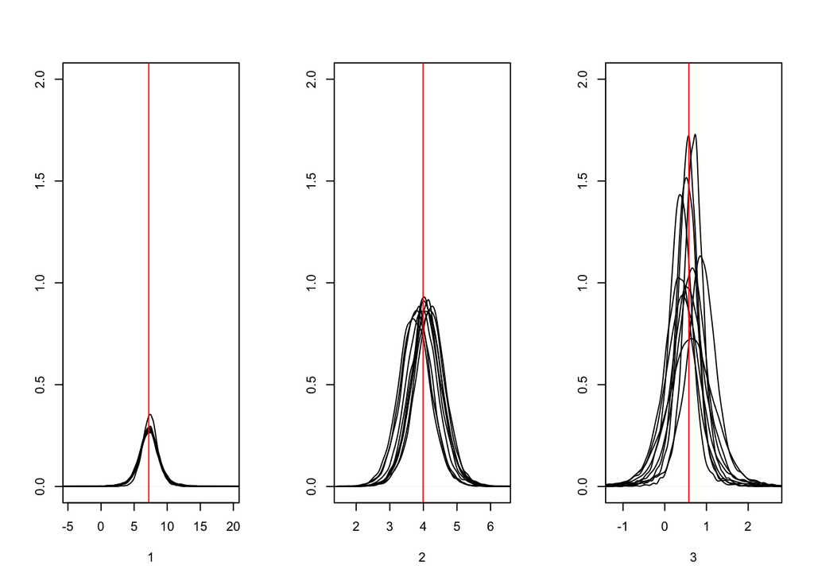

```r
### Plot the ten posteriors and the OLS estimator for each coefficent
par(mfrow=c(1,3))
for (i in 1:3) {
    plot(density(BETA[,i,1]),type="l",ylim=c(0,2),ylab="",
         xlab=i,main="")
    for (j in 2:10) {
        lines(density(BETA[,i,j]))
    }
    abline(v=fit$coefficients[i],col="red")
}
```

As we can see, the posterior estimators have large amount of overlapping, and the peaks approximately appear at where the OLS estimators locate.

Again, we take one more step to investigate the residuals.

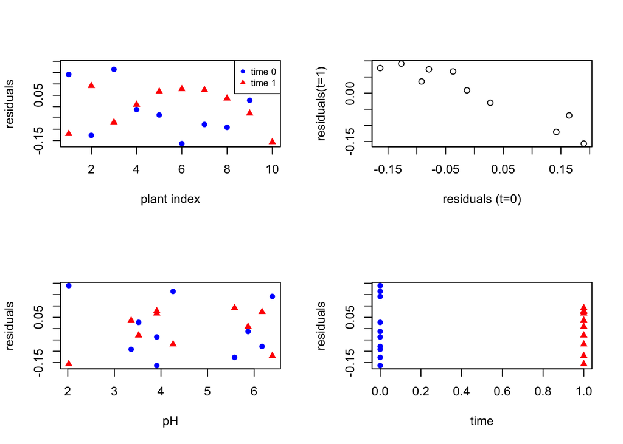

```r
post.mean <- matrix(rep(NA,3*10),ncol=10)
for (i in 1:3) {
    for (j in 1:10) {
        post.mean[i,j] <- mean(BETA[,i,j])
    }
}
res2 <- NULL
for (i in 1:10) {
    ind <- (2*i-1):(2*i)
    res2 <- c(res2,y[ind]-post.mean[,i]%*%t(X[ind,]))
}

par(mfrow=c(2,2))
ind <- which(x[,1]==0)
plot(1:10,res2[ind],ylim=c(min(res2),max(res2)),col="blue",pch=16,
     xlab="plant index",ylab="residuals")
points(1:10,res2[-ind],col="red",pch=17)
legend("topright",legend=c("time 0","time 1"),pch=c(16,17),col=c("blue","red"),
       cex=0.75)
plot(res2[ind],res2[-ind],xlab="residuals (t=0)",ylab="residuals(t=1)")
plot(x[which(x[,1]==0),2],res2[ind],xlab="pH",ylab="residuals",
     ylim=c(min(res2),max(res2)),xlim=c(min(x[,2]),max(x[,2])),
     col="blue",pch=16)
points(x[which(x[,1]==1),2],res2[-ind],col="red",pch=17)
plot(x[which(x[,1]==0),1],res2[ind],xlab="time",ylab="residuals",
     ylim=c(min(res2),max(res2)),xlim=c(0,1),
     col="blue",pch=16)
points(x[which(x[,1]==1),1],res2[-ind],col="red",pch=17)
```

```r
cor(cbind(fit$residuals[ind],fit$residuals[-ind]))
```

```
##           [,1]      [,2]
## [1,] 1.0000000 0.9321597
## [2,] 0.9321597 1.0000000
```

```r
cor(cbind(res2[ind],res2[-ind]))
```

```
##            [,1]       [,2]
## [1,]  1.0000000 -0.9473386
## [2,] -0.9473386  1.0000000
```

Two variance-covariance matrices are also generated for us to check the correlation between residuals at time 0 and time 1. This time, we have (almost) negatively correlated residuals. This is totally different from the OLS model we fitted previously.

## Problem 4

Recall the heart transplant mortality data exercise discussed in class at the end of Chapter 8. The data are in the file `hearttransplants.csv`. Implement a Metropolis-Hastings algorithm to fit a Bayesian hierarchical model to estimate the mortality rates and the shrinkage effect for each hospital. Rank the hospitals based on the mortality rates after heart transplant surgery. Provide some posterior predictive checks to demonstrate that your MH algorithm has converged.

## Solution

The following solution contains some predefined functions in `LearnBayes` package.

```r
heart <- read.csv("hearttransplants.csv")

SIMS <- 10000
y <- heart$y
e <- heart$e

poissgamexch <- function (theta,datapar) {
    y <- datapar$data[,2]
    e <- datapar$data[,1]
    z0 <- datapar$z0
    alpha <- exp(theta[1])
    mu <- exp(theta[2])
    beta <- alpha/mu
    logf <- function(y,e,alpha,beta) {
        lgamma(alpha+y)-(y+alpha)*log(e+beta)+alpha*log(beta)-lgamma(alpha)
    }
    val <- sum(logf(y,e,alpha,beta))
    val <- val+log(alpha)-2*log(alpha+z0)
    return(val)
}
```

```r
par(mfrow=c(1,1))
datapar <- list(data=heart,z0=0.5)
start <- c(4,-7)
fitgibbs <- gibbs(poissgamexch,start,SIMS,c(2,.5),datapar)

# gibbs() implements Metropolis within Gibbs

alpha <- exp(fitgibbs$par[,1])
mu <- exp(fitgibbs$par[,2])
lam1 <- rgamma(10000,y[1]+alpha,e[1]+alpha/mu)
quantile(lam1,c(0.05,0.95))
```

```
##           5%          95%
## 0.0003884816 0.0015084187
```

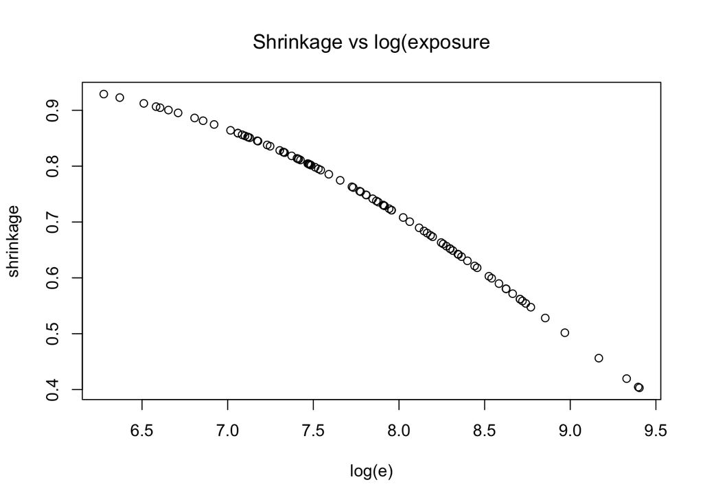

```r
shrink <- function(i) {
    mean(alpha/(alpha+e[i]*mu))
}
hospital=1:94
shrinkage <- sapply(hospital,shrink)
plot(log(e),shrinkage,main="Shrinkage vs log(exposure")
```

As the logarithm of exposure increases, the shrinkage effect decreases. This makes sense, as the sample size of a hospital gets larger, the more information it provides, generally it becomes more “stable”.

```r
mrate <- function(i) {
    mean(rgamma(10000,y[i]+alpha,e[i]+alpha/mu))
}

meanrate <- sapply(hospital,mrate)
c("best:",hospital[meanrate==min(meanrate)],min(meanrate),
  "worst:",hospital[meanrate==max(meanrate)],max(meanrate))
```

```
## [1] "best:"                "85"                   "0.000544112643433887"
## [4] "worst:"               "68"                   "0.0013855916262679"
```

So the 85th hospital has the lowest mortality rate ($0.054%$), the 68th hospital has the highest ($0.139%$).

A detailed ranking of hospitals is also provided ordered from lowest mortality rate to highest.

```r
srate <- sort(meanrate,decreasing=T)
search.hospital <- function(i) {
    which(meanrate==srate[i])
}
(shospital <- sapply(94:1,search.hospital))
```

```
##  [1] 85 63 84 73 70 76 90 81 49 50 60 19 89 67 66 78 64 58 77 57 17 55 37
## [24]  6 27 54 16 10 92  7 13 11 26 12 74 51  1  2 39 56 61 35 65  8 44 47
## [47] 79 22 21 20 72 59 82  5 86 80  4 48 45 40 29 75 33 28 88 91 14 25 41
## [70] 36 18 46 24  3 32 53 34 71 87 52 42 15 69 83 31 43 62 94 30  9 38 23
## [93] 93 68
```

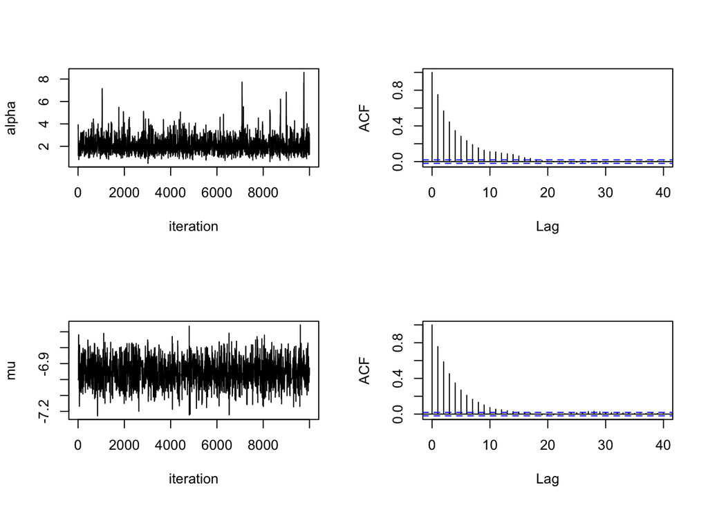

```r
par(mfrow=c(2,2))
plot(fitgibbs$par[1:SIMS,1],type="l",xlab="iteration",ylab="alpha")
acf(fitgibbs$par[1:SIMS,1],main="")
plot(fitgibbs$par[1:SIMS,2],type="l",xlab="iteration",ylab="mu")
acf(fitgibbs$par[1:SIMS,2],main="")
```

```r
par(mfrow=c(1,1))

fitgibbs$accept
```

```
##       [,1]   [,2]
## [1,] 0.314 0.1997
```

```r
effectiveSize(fitgibbs$par[,1])
```

```
##     var1
## 1223.606
```

```r
effectiveSize(fitgibbs$par[,2])
```

```
##     var1
## 1302.947
```

Finally, we check the effective sample sizes of parameters. They both exceed 1000. The acceptance rates are $0.314$ and $0.1997$. Not ideal, but the results are acceptable. To conclude, we believe the algorithm converged.

## Problem 5

Non-conjugate hierarchical models: An experiment is conducted to estimate $\theta$, the probability of developing a tumor in a population of female rats that receive a dose of drug X. (Such studies are routinely done in the evaluation of drugs for possible clinical application). Suppose $J$ such experiments have been conducted historically. In the $j^{th}$ historical experiment, let the number of rats with tumors be $y_j$ and let $n_j$ be the total number of rats tested in the $j^{th}$ experiment. We model the $y_j$’s as independent binomial data, given the sample size $n_j$, and study-specific means $\theta_j$.

Suppose we assume that the tumor probabilities $\theta$ follow a normal distribution on the log-odds scale, that is, $\text{logit}(\theta_j)\sim N(\mu,\tau^2)$.

### (a)

Write the joint posterior density $p(\mathbf{\theta},\mu,\tau^2\mid\mathbf{y})$ (where $\mathbf{\theta}=(\theta_1,\dots,\theta_J)$ and $\mathbf{y}=(y_1,\dots,y_J)$).

### Solution:

$$\begin{split}
p(\theta,\mu,\tau^2\mid \mathbf{y})&\propto p(\theta,\mu,\tau^2)p(\mathbf{y}\mid\theta,\mu,\tau^2)\\
&=p(\theta,\mu,\tau^2) p(\mathbf{y}\mid\theta)\\
&=p(\theta\mid \mu,\tau^2)p(\mu,\tau^2)\\
&=p(\mu,\tau^2)\cdot \prod^J_{j=1}\left(\theta_j^{-1}(1-\theta_j)^{-1}\tau^{-1}\exp{(-(\frac12\text{logit}(\theta_j)-\mu)^2/\tau^2}\right)\\
&\cdot\prod^J_{j=1}\left(\theta_j^{y_j}(1-\theta_j)^{n_j-y_j}\right)
\end{split}$$

### (b)

To obtain the marginal posterior distribution $p(\mu,\tau^2\mid \mathbf{y})$, we can integrate the joint distribution in (a) over $\mathbf{\theta}$. Show that this integral has no closed-form expression.

### Solution:

There is no way to integrate such complex integrand above. Nothing looks familiar.

### (c)

We can also compute the marginal posterior distribution of $(\mu,\tau^2)$ using the conditional probability formula,

$$p(\mu,\tau^2\mid\mathbf{y})=\frac{p(\mathbf{\theta},\mu,\tau^2\mid\mathbf{y})}{p(\mathbf{\theta}\mid\mu,\tau^2,\mathbf{y})}$$

Why is the above expression not helpful to evaluate $p(\mu,\tau^2\mid\mathbf{y})$?

In practice, we can solve this problem by normal approximation, importance sampling, and MCMC simulation.

### Solution:

Here we only know $p(\theta\mid\mu,\tau^2,\mathbf{y})$ is proportional to the target formula. However, in order to evalutate $p(\mu,\tau^2\mid\mathbf{y})$, we need to know $p(\theta\mid\mu,\tau^2,\mathbf{y})$ explicitly, because our goal is to use this density to find another density that depends on $\mu$ and $\tau$.

## References

- What’s the difference between correlation and simple linear regression?, https://stats.stackexchange.com/questions/2125/whats-the-difference-between-correlation-and-simple-linear-regression
- LearnBayes: Functions for Learning Bayesian Inference, https://cran.r-project.org/web/packages/LearnBayes/index.html